# Omicidi ad opera della polizia negli Stati Uniti

Thomas Rosso

23/06/2020

## Introduzione

Successivamente alla pandemia causata dal COVID-19, un’ ulteriore fatto di cronaca ha sconvolto l’equilibrio mondiale: l’ omicidio di George Floyd per asfissia causato da un agente americano a Minneapolis, Minnesota. Tale fatto, ha causato innumerevoli rivolte negli Stati Uniti, con manifestazioni, inizialmente pacifiche ma che successivamente sono sfociate in veri e propri saccheggi, distruzione e vandalismo. Navigando nei vari social, guardando i vari telegiornali o semplicemente studiando la storia recente, vi sono innumerevoli riferimenti al fatto che la comunità afroamericana sia spesso vittima di attacchi da parte della polizia, i quali usando la propria posizione di superiorità commettono omicidi a sfondo razziale. Grazie ad i numerosi dati che il web mette a disposizione, l’obiettivo di questo progetto è analizzare i dati registrati sugli omicidi compiuti dalla polizia e confrontarli con la popolazione americana.

Per questo progetto verranno impiegati 2 Dataset, il primo corrispondente agli spari fatali dai poliziotti dall’anno 2015 al 2020; il secondo sul censimento americano avvenuto nel 2015.

In questo progetto si cercherà di rispondere alle seguenti domande:

- Quali sono i generi più colpiti?
- C’è una discriminazione verso le persone di colore?
- Come si distribuiscono gli omicidi negli anni?
- Quali sono le città e gli stati più colpiti?
- C’è una correlazione tra le persone in fuga/presenza di armi e l’ età?
- C’è una correlazione tra la povertà percentuale di una città e gli omicidi ad opera della polizia?

## Importazione e pulizia dei Dataset

```r
#Caricamento librerie
library(readr)
library(dplyr)
library(ggplot2)
library(lubridate)
library(modelr)
library(tidyr)
library(gridExtra)
library(scales)
library(reshape2)

#Caricamento Dataset
fpsd = read.csv("fpsd.csv", na.strings = "", stringsAsFactors = TRUE)
us_census_2015 = read.csv("acs2015_county.csv")

#Pulizia dataset
fpsd = na.omit(fpsd)
us_census_2015 = us_census_2015 %>%
  rename("H"="Hispanic","W"="White","B"="Black","N"="Native","A"="Asian","O"="Pacific")
us_states = unique(us_census_2015$State)
us_county = unique(us_census_2015$County)
us_races = unique(fpsd$race)

us_census_2015 = us_census_2015[us_census_2015$State != "Puerto Rico",]

#Aggiustiamo la data
fpsd = fpsd %>%
  mutate(date=factor(date))
fpsd = fpsd %>%
  mutate(date = as.Date(date,format="%Y-%m-%d"))
```

Successivamente all’ importazione dei Data set ed una breve pulizia degli stessi, possiamo procedere con la nostra analisi.

## Analisi preliminare

In questa prima parte del progetto, provvederemo ad analizzare quella che è una visione “dall’ alto” del database. Innanzitutto proviamo a visualizzare qual è il genere (maschile o femminile) più colpito:

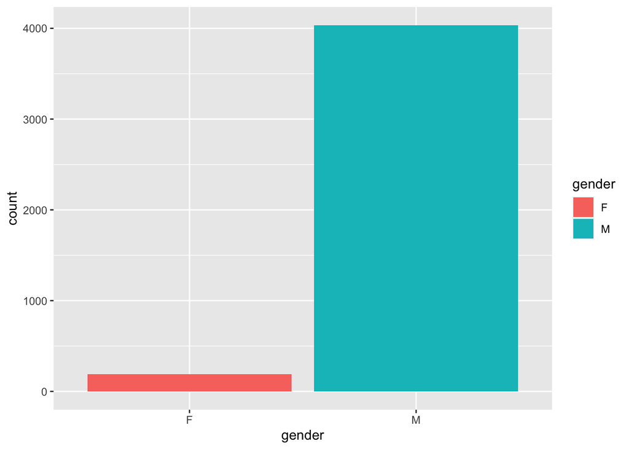

```r
ggplot(data = fpsd) +
  geom_bar(mapping = aes(x = gender ,fill=gender))
```

Come si può facilmente osservare, il genere maschile è quello più colptio. Successivamente, concentriamo la nostra attenzione sull’ età delle vittime:

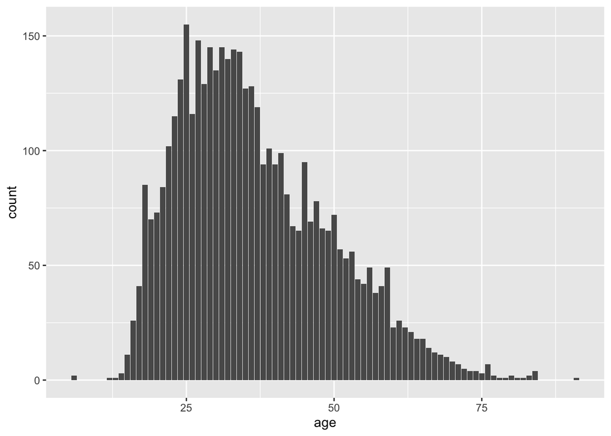

```r
#Grafico distribuzione vittime per eta
ggplot(data=fpsd) +
    geom_bar(mapping = aes(x = age))
```

In questo primo grafico, osserviamo la distribuzione dell’ età delle vittime, come si osserva facilmente, il maggior numero di vittime ha un’ età compresa tra i 20 ed i 30 anni. Nel grafico sottostante, invece, si è preferito visulizzare le vittime tramite dei punti nel piano; in modo da poter osservare meglio la loro distribuzione. E’ stato evidenziato in modo significativo la vittima con età più bassa rispetto all’ intero dataset: *Jeremy Mardis*. Risalente al caso di cronaca del 2015, questo omicidio ha riguardato un bambino di solamente 6 anni per mano delle forze dell’ ordine.

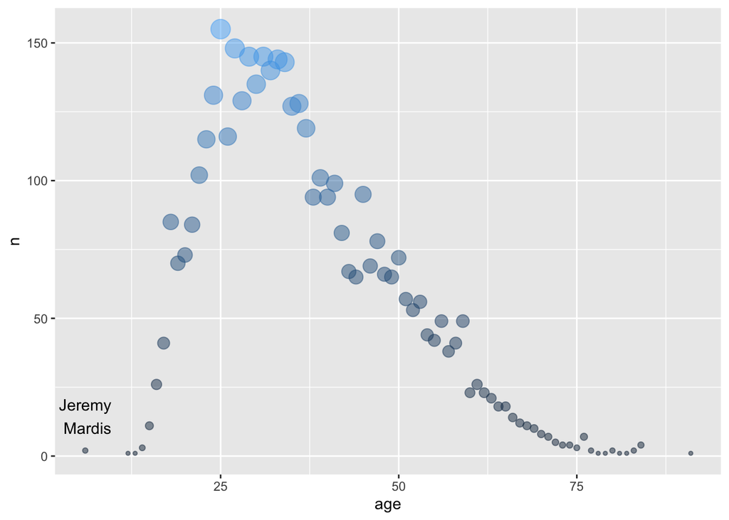

```r
#Omicidi per eta
fpsd %>%
  group_by(age) %>%
  summarise(n=n()) %>%
    ggplot(mapping=aes(x=age,y=n)) +
      geom_point(mapping=aes(size=n,color=n),alpha=0.5,show.legend = FALSE) +
      geom_text(aes(label=ifelse(age<10,as.character("Jeremy\n Mardis"),'')),hjust=0.5,vjust=-0.5)
```

```r
mean(fpsd$age)
```

```
## [1] 36.58584
```

```r
median(fpsd$age)
```

```
## [1] 34
```

```r
min(fpsd$age)
```

```
## [1] 6
```

```r
max(fpsd$age)
```

```
## [1] 91
```

Come ultima analisi preliminare, vorrei concentrarmi sui gruppi etnici più colpiti, utilizzando sempre un diagramma a barre:

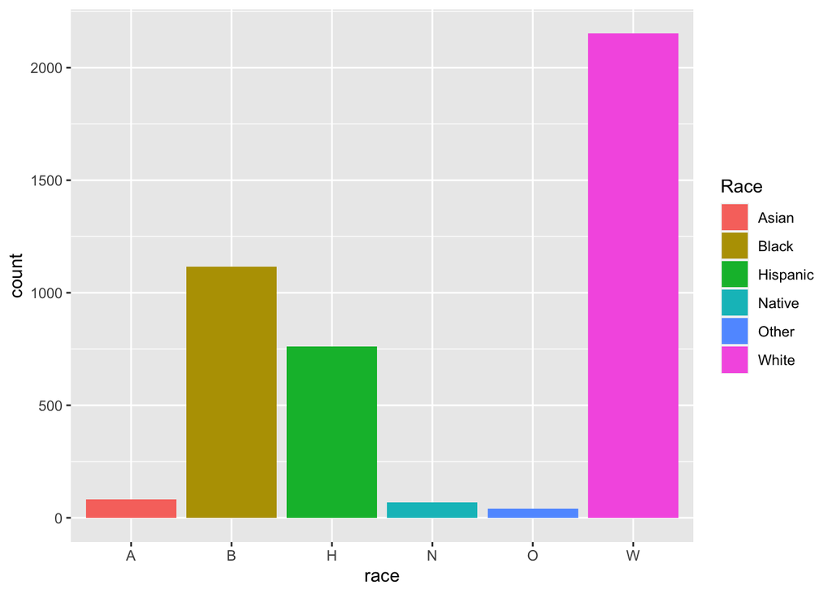

```r
ggplot(data = fpsd) +
  geom_bar(mapping = aes(x = race,fill=race)) +
  scale_fill_discrete(name = "Race", labels = c("Asian", "Black", "Hispanic", "Native", "Other", "White"))
```

Per concludere questa prima parte, facciamo il punto sui dati ottenuti in questo inizio; da una prima occhiata pare evidente quanto ci siano delle chiare indicazioni sulle vittime più colpite, in particolare sulla presenza in maggior numero di maschi bianchi con un eta compresa tra i 20 e 30 anni. Queste indicazioni tuttavia non devono trarci in inganno in quanto mancano i dati relativi alla distribuzione delle varie etnie all’ interno degli stati uniti. Nel prossimo punto provvederemo a risolvere questo problema e ad ottenere risultati più completi.

## Distribuzione delle vittime all’ interno degli Stati Uniti

Come sancito nel punto precedente, in questa parte verrà approfondita la distribuzione delle varie etnie all’ interno degli stati uniti; per farlo verrà utilizzato il dataset relativo al censimento americano effettuato nel 2015.

Come primo passo aggiustiamo il dataset relativo al censimento, rimuovendo i campi non necessari:

```r
#Rimuovo i campi che non verrano utilizzati
us_census_2015 = us_census_2015 %>%
  select(State:Citizen,Poverty,ChildPoverty)
```

Con un dataset pulito ed ordinato, proviamo a visulizzare alcuni dati riguardo alla popolazione statunitense:

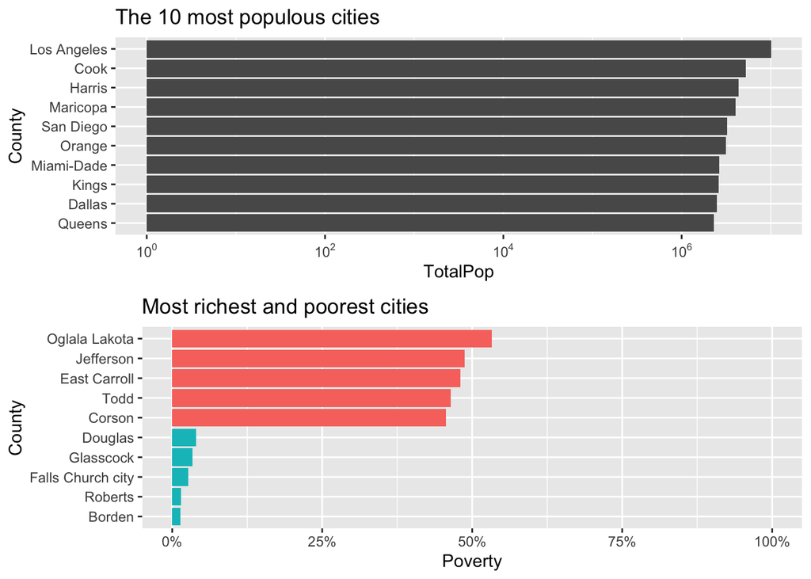

```r
#Visulizziamo le citta con più popolazione
plot1=us_census_2015 %>%
  arrange(-TotalPop) %>%
  select(State, County, TotalPop) %>%
  head(10) %>%
  ggplot(aes(x=reorder(County,TotalPop), y=TotalPop)) +
    geom_bar(stat="Identity",show.legend = FALSE) +
    ggtitle("The 10 most populous cities") +
    xlab("County") +
    coord_flip()  +
    scale_y_log10(breaks = trans_breaks("log10", function(x) 10^x),
              labels = trans_format("log10", math_format(10^.x)))


#Visulizziamo le citta piu ricche (tasso di povertà piu basso)
richest = us_census_2015 %>%
  arrange(Poverty) %>%
  select(State, County, Poverty) %>%
  head(5)

poor = us_census_2015 %>%
  arrange(-Poverty) %>%
  select(State, County, Poverty) %>%
  head(5)

top_and_last = rbind(richest,poor) %>%
  arrange(Poverty)

#Visulizziamo le citta piu povere (tasso di povertà piu alto)
  plot2=ggplot(data=top_and_last,aes(x=reorder(County,Poverty), y=Poverty,fill=Poverty<20)) +
    geom_bar(stat="Identity",show.legend = FALSE) +
    scale_y_continuous(limits=c(0, 100),labels = function(x) paste0(x, "%")) +
    ggtitle("Most richest and poorest cities") +
    xlab("County") +
    coord_flip()

grid.arrange(plot1,plot2)
```

Dal dataset relativo al censimento siamo risuciti ad estrapolare alcune due caratteristiche importanti:

- Le 10 città più popolate degli stati uniti, in cui domina Los Angeles (California) con più di 10 milioni di abitanti
- Le 5 città più ricche e più povere degli stati uniti, di cui si aggiudica il primato Borden con un tasso di povertò poco sopra l’1% e l’ ultimo posto lo prende Oglala Lakota con una percentuale oltre il 50%.

Un’ osservazioni importante, tuttavia, è da fare anche qua, in quanto questi dati non tengono conto della dimensione totale dello stato/citta; comunque sia riescono a darci una bella vista dall’ “alto” degli Stati Uniti d’ America.

Procediamo ora a rispondere a quella che probabilmente è la domanda più importante dell’ intera analisi: esiste una qualche specie di discriminazione razziale?

```r
#Calcoliamo la distribuzione totale delle etnie negli stati uniti

#Popolazione totale neglu stati uniti
total_pop = sum(us_census_2015$TotalPop)
#Distribuzione etnica negli stati uniti
race_distribution = us_census_2015 %>%
  mutate(H=(H/100)*TotalPop,
         W=(W/100)*TotalPop,
         B=(B/100)*TotalPop,
         N=(N/100)*TotalPop,
         A=(A/100)*TotalPop,
         O=(O/100)*TotalPop) %>%
  select(State,County,TotalPop,H:O)

#Calcoliamo la distribuzione totale delle etnie della popolazione
totalH = sum(race_distribution$H)
totalW = sum(race_distribution$W)
totalB = sum(race_distribution$B)
totalN = sum(race_distribution$N)
totalA = sum(race_distribution$A)
totalO = sum(race_distribution$O)

#Calcoliamo le percentuali
percentH = totalH/total_pop
percentW = totalW/total_pop
percentB = totalB/total_pop
percentN = totalN/total_pop
percentA = totalA/total_pop
percentO = totalO/total_pop

#Inseriamo i risultati in un dataframe
race_distribution_percent = data.frame(
  race = us_races,
  percentage = c(percentA,percentW,percentH,percentB,percentO,percentN)
)
race_distribution_percent
```

```
##   race  percentage
## 1    A 0.050717344
## 2    W 0.623210038
## 3    H 0.171312670
## 4    B 0.122541905
## 5    O 0.001483497
## 6    N 0.006586542
```

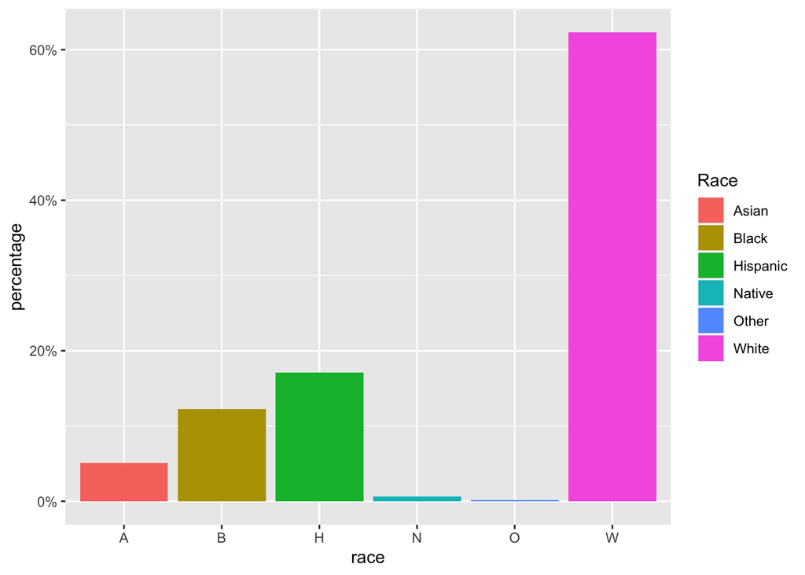

```r
#Controprova per i risultati ottenuti dalle percentuali
ggplot(data=race_distribution_percent, aes(x=race,y=percentage, fill=race)) +
  geom_bar(stat = "identity") +
  scale_fill_discrete(name = "Race", labels = c("Asian", "Black", "Hispanic", "Native", "Other", "White")) +
  scale_y_continuous(labels = percent_format())
```

Finalmente, dopo quest’ elaborazione di dati possiamo visulizzare i dati relativi alla comparazione tra gli omicidi ad opera della polizia e la distribuzione delle etnie all’ interno della popolazione. Per farlo è sufficiente comparare le due pecentuali ed osservarne i risultati.

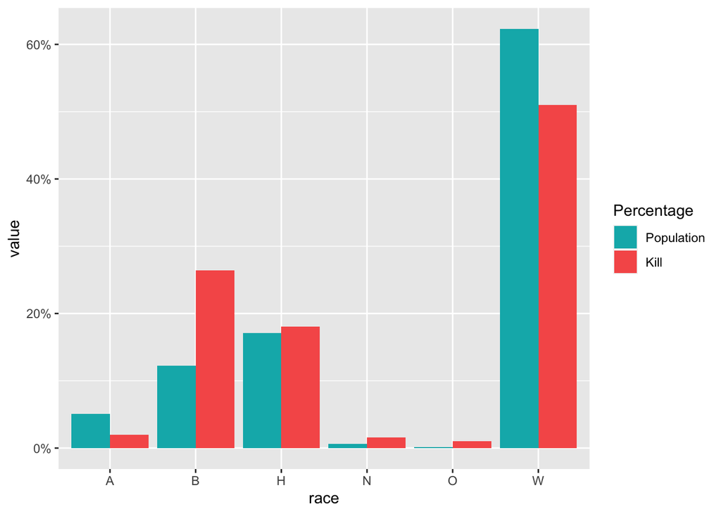

```r
#Analizziamo la distribuzione percentuale delle vittime (divise per etnie)
fpsd_distrib = fpsd %>%
  group_by(race) %>%
  summarise(n=n())
total_victim = sum(fpsd_distrib$n)
fpsd_distrib = fpsd_distrib %>%
  mutate(percentage_of_kill = n/total_victim) %>%
  select(race,percentage_of_kill)

#Uniamo i due valori all' interno di un unico dataset
total_data = inner_join(race_distribution_percent,fpsd_distrib,by="race")
df_long <- melt(total_data, id.var = "race")


ggplot(df_long, aes(x = race, y = value, fill = variable)) +
  geom_bar(stat = "identity", position = "dodge") +
  scale_fill_manual( values = c("#00B4B8", "#F65D57"),name="Percentage",labels=c("Population","Kill")) +
  scale_y_continuous(labels = percent)
```

Dai dati estrapolati, risulta evidente come ci sia una chiara descriminazione. Questa si può osservare in 2 casi distinti: il primo nella popolazione afroamericana, mentre il secondo nei nativi americani. Risulta quindi che le proteste trovino un forte fondamento nell’ analisi dei dati.

## Distribuzione degli omicidi nel corso degli anni

Si è giunti finalmente ad una risposta alla domanda più importante. Il nuovo obiettivo è ora quello di approfondire ulteriormente il dataset per osservare come gli omicidi si distribuiscono negli anni e osservare magari una qualche forma di aumento o diminuzione. Una premessa importante da fare è che, dato che il 2020 non si è ancora concluso, l’ ultima colonna relativa agli anni non è da prendere in considerazione, prendendo in esame le variazioni annue.

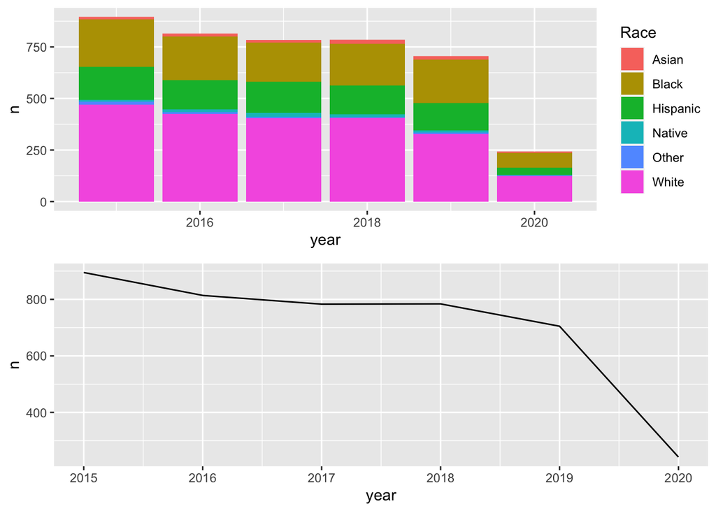

```r
#Estrazione dei dati relativi agli omicidi nei giorni
daily = fpsd %>%
  select(race,date) %>%
  group_by(date,race) %>%
  summarise (n=n())

daily <- daily %>%
  mutate(year = year(date)) %>%
  mutate(month = month(date))

daily2 = fpsd %>%
  mutate(year=year(date)) %>%
  group_by(year) %>%
  summarise(n=n())

#Visualizzazione dei risultai
plot_time = ggplot(daily,mapping=aes(year,n,fill=race)) +
  geom_bar(stat = "identity") +
  scale_fill_discrete(name = "Race", labels = c("Asian", "Black", "Hispanic", "Native", "Other", "White"))


plot4 = ggplot(daily2,mapping=aes(year,n)) +
  geom_line()

grid.arrange(plot_time,plot4)
```

Un’ osservazione immediata dal grafico è il leggero calo delle vittime dal 2015 ad oggi, con un impercettibile aumento nel 2018.

## Città e stati più colpiti

Dopo un’ analisi temporale, per estendere il concetto di conoscenza, la cosa più immediata è stilare un grafico che rappresenti le città e gli stati più colpiti, in modo da poterle eventualmente identificare come “più pericolose”.

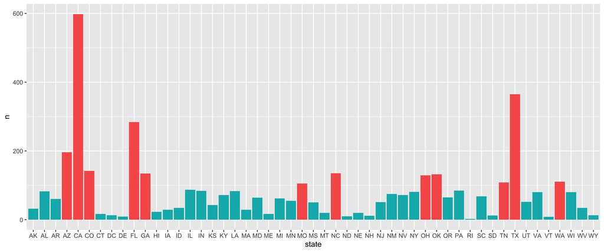

```r
#Stati piu pericolosi
most_dangerous_states = fpsd %>%
  group_by(state) %>%
  summarise(n=n())

ggplot(data=most_dangerous_states,mapping = aes(state,n,fill=n>100)) +
  geom_bar(stat="Identity",position=position_dodge(width=20),show.legend = FALSE) +
  scale_fill_manual( values = c("#00B4B8", "#F65D57"))
```

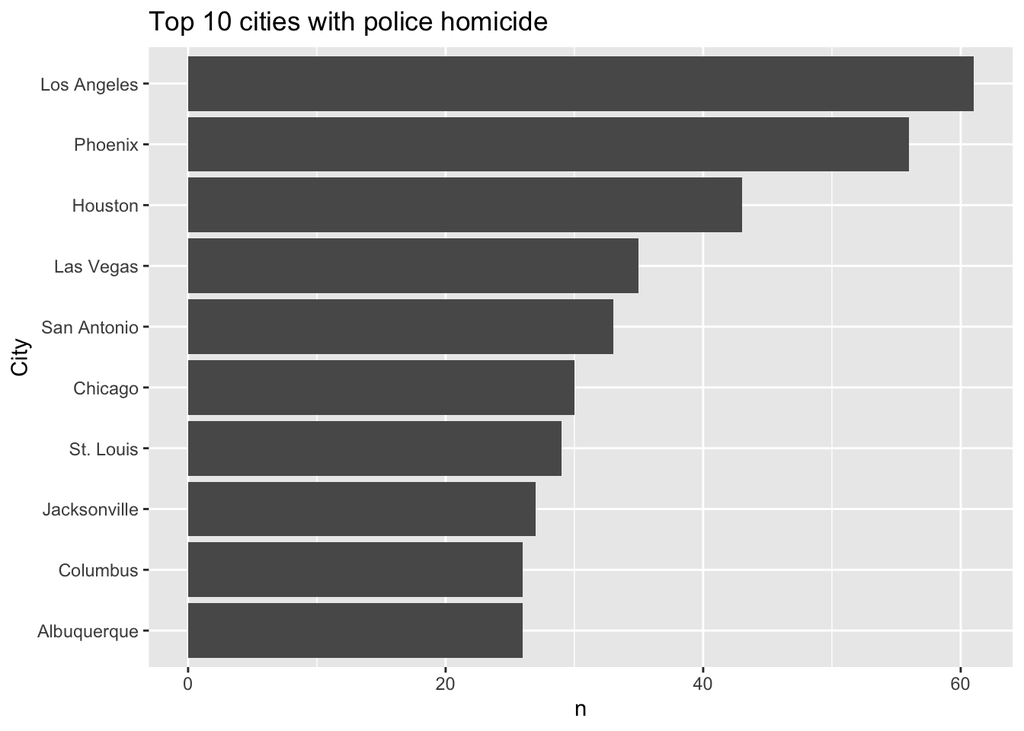

```r
most_dangerous_cities = most_dangerous_states %>%
  filter(n>100)

most_dangerous_cities = fpsd %>%
  group_by(state,city) %>%
  summarise(n=n()) %>%
  arrange(-n) %>%
  head(10)

ggplot(data=most_dangerous_cities,aes(x=reorder(city,n), y=n)) +
    geom_bar(stat="Identity",show.legend = FALSE) +
    #scale_y_continuous(limits=c(0, 100),labels = function(x) paste0(x, "%")) +
    ggtitle("Top 10 cities with police homicide") +
    xlab("City") +
    coord_flip()
```

Stilando una classifica delle 10 città più pericolose, spicca Los Angeles(CA), in cui gli omici da parte dei dipartimenti di polizia super quota 60.

## Individui in fuga

All’ interno del dataset, una feature curiosa, è quella riguardante la reazione dell’ individuo successivamente all’ arresto; in particolare se si è verificata una fuga (e anche come è stata effettuata) o se l’ individuo non ha tentato di sfuggire agli agenti. Oltre a tutto ciò, sarà possibile visionare una lista delle armi più comuni utilizzate dalle vittime.

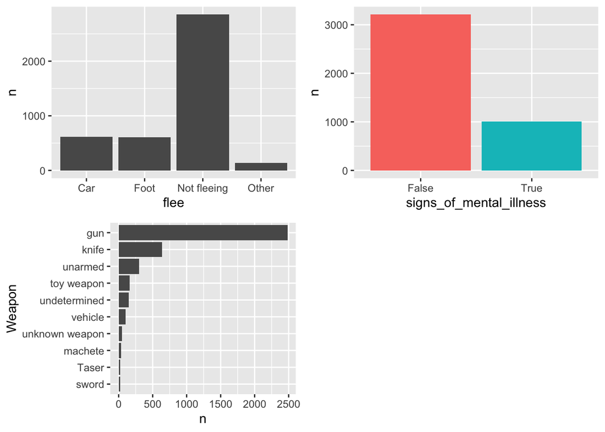

```r
#Estraiamo i valori della colonna flee e armed
flee = unique(fpsd$flee)
armed = unique(fpsd$armed)

#Fuga degli individui
flee_categories = fpsd %>%
  group_by(flee) %>%
  summarise(n=n())

#Individui armati
armed_categories = fpsd %>%
  group_by(armed) %>%
  summarise(n=n()) %>%
  arrange(-n)

#Rappresentiamo i risultati graficamente
#DA SPOSTARE SU
plot_flee = ggplot(data=flee_categories, mapping=aes(flee,n))+
  geom_bar(stat = "identity")

plot_weapon = armed_categories %>%
  arrange(-n) %>%
  head(10) %>%
  ggplot(mapping=aes(reorder(armed,n),n))+
  geom_bar(stat = "identity") +
  coord_flip() +
  xlab("Weapon")

plot_somi = fpsd %>%
  group_by(signs_of_mental_illness) %>%
  summarise(n=n()) %>%
  ggplot(mapping=aes(signs_of_mental_illness,n, fill=signs_of_mental_illness)) +
  geom_bar(stat = "Identity",show.legend = FALSE)

grid.arrange(plot_flee,plot_somi,plot_weapon,nrow=2)
```

Ora cerchiamo una correlazione tra gli individui in fuga e l’età. Come è logico aspettarsi, una persona giovane magari tenterà in modo maggiore la fuga rispetto ad una più “anziana”, date le caratteristiche fisiche più agili. Per verificare la nostra ipotesi useremo un test per le ipotesi Chi-Quadrato, che permette di ottenere un’ eventuale correlazione tra due variabili categoriali.

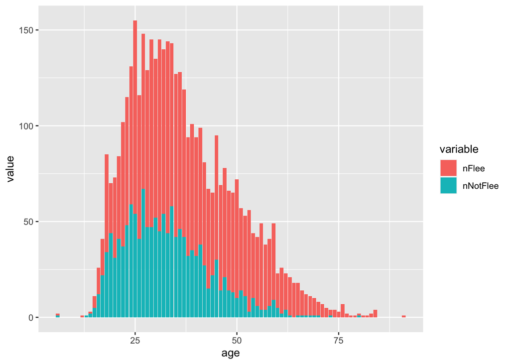

```r
#Persone che scappano ed eta

flee_people = fpsd %>%
  filter(flee=="Not fleeing") %>%
  group_by(age) %>%
  summarise(n=n()) %>%
  rename(nFlee = n)

not_flee = fpsd %>%
  filter(flee!="Not fleeing") %>%
  group_by(age) %>%
  summarise(n=n()) %>%
  rename(nNotFlee = n)

#Unione dei dataset
complete_flee = full_join(flee_people,not_flee,by="age")
complete_flee[is.na(complete_flee)] = 0
df_long4 = melt(complete_flee, id.var = "age")

#Stampiamo il grafico
ggplot(df_long4, mapping = aes(age,value,fill=variable)) +
  geom_bar(stat="Identity")
```

```r
#Operiamo il test
chisq.test(complete_flee)
```

```
##
##  Pearson's Chi-squared test
##
## data:  complete_flee
## X-squared = 3006.6, df = 148, p-value < 2.2e-16
```

Già nel grafico si possono osservare le nostre ipotesi, ma questo trova ancora più riscontro nel test di Chi Quadrato. Dato il valore del P-Value, possiamo scartare l’ ipotesi nulla e affermare che esiste una correlazione tra età ed individui in fuga.

Un ulteriore correlazione interessante può essere quella tra la presenza di armi ed età. Molto spesso nei media si ascoltano notizie ruguardanti strazianti stragi all’ interno delle scuole da parte degli individui più giovani. Con questa ricerca di correlazione si vuole osservare se è presente un collegamento tra il possedimento di un’ arma e l’aumentare dell’ età.

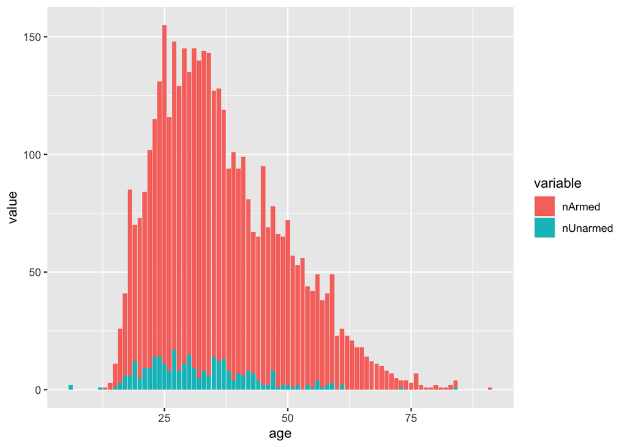

```r
#Correlazione tra individui armati ed età
armed_people = fpsd %>%
  filter(armed!="unarmed") %>%
  group_by(age) %>%
  summarise(n=n()) %>%
  rename(nArmed=n)

unarmed_people = fpsd %>%
  filter(armed=="unarmed") %>%
  group_by(age) %>%
  summarise(n=n()) %>%
  rename(nUnarmed=n)

complete_armed = full_join(armed_people,unarmed_people, by="age")
complete_armed[is.na(complete_armed)] = 0
df_long3 <- melt(complete_armed, id.var = "age")

ggplot(df_long3, mapping = aes(age,value,fill=variable)) +
  geom_bar(stat="Identity")
```

```r
#Proviamo ad osservare una correlazione
chisq.test(complete_armed)
```

```
##
##  Pearson's Chi-squared test
##
## data:  complete_armed
## X-squared = 2869.1, df = 148, p-value < 2.2e-16
```

Anche in questo caso, è presente un p-value molto basso, di conseguenza possiamo osservare una relazione forte sia tra l’ età e gli individui in fuga, sia tra l’eta degli individui e la presenza di armi di qualsiasi genere.

## Rapporto tra omicidi e povertà

In questa ultima parte, si è deciso di tornare ai dati presenti nel dataset del censimento, in particolare quello riguardante la povertà. L’obiettivo ultimo è la ricerca di una correlazione tra i casi di omicidio e la povertà di uno stato/città.

```r
fpsd_poverty = us_census_2015 %>%
  mutate(Poverty = (Poverty/100)*TotalPop) %>%
  select(County,TotalPop,Poverty) %>%
  group_by(County) %>%
  summarise(TotalPop=sum(TotalPop),Poverty=sum(Poverty)) %>%
  rename(city=County)


crime_and_poverty = inner_join(fpsd,fpsd_poverty,by="city") %>%
  select(state,city,TotalPop,Poverty) %>%
  group_by(city) %>%
  summarise(Totalcrime=n(),TotalPop = unique(TotalPop), Poverty=unique(Poverty)) %>%
  mutate(PovertyPercentage = Poverty/TotalPop)
```

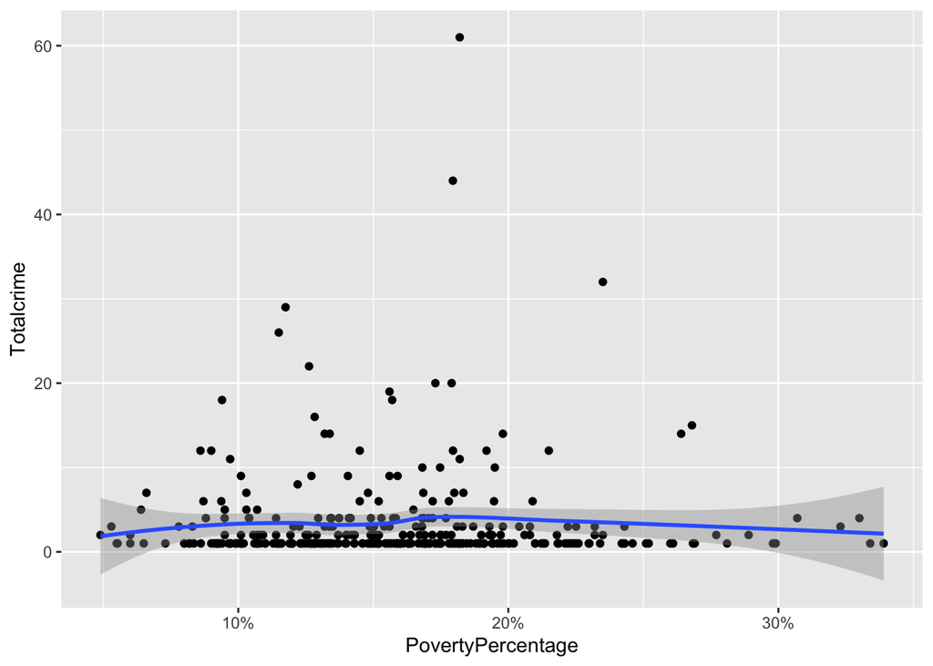

```r
#Rappresentazione dei dati
ggplot(data=crime_and_poverty,mapping=aes(x=PovertyPercentage,y=Totalcrime)) +
  geom_point() +
  scale_x_continuous(labels = percent) +
  geom_smooth(method = "loess")
```

```r
#Test di correlazione
chisq.test(crime_and_poverty$PovertyPercentage,crime_and_poverty$Totalcrime)
```

```
##
##  Pearson's Chi-squared test
##
## data:  crime_and_poverty$PovertyPercentage and crime_and_poverty$Totalcrime
## X-squared = 5627, df = 5865, p-value = 0.9869
```